# Sentiment Analysis of headlines about US presidents in their first year of mandate

This is the final project of the Automated Media Content Analysis module, as part of the program *Mannheim Master in Data Science* of the University of Mannheim, developed by Souza, V. F. during the winter semester of 2021/22.

# 1. Introduction

With the wide spread of instant messaging apps such as Whatsapp and Telegram, and the frequent restriction of full-article reading by famous journals to subscribers, news' headlines and snippets have become more important in the information sharing dynamic. Headlines are the titles, often in bold and greater size, while snippets are the small text that can be read right below the headlines in instant messaging apps' and social media's pre-visualization. Both texts plus the image that appears when sharing articles are the newspaper's chance of convincing potential readers that the full content is worth a subscription, and are certainly read more frequently than the article's paragraphs.

In order to become interesting and curious, these short texts might carry sentiment, irony, analogies, and even mystery. Their vocabulary must be carefully chosen to make the article at the same time informative and instigating, and it might also reveal the newspaper's position towards some subject. Specifically in the political environment, measuring the sentiment of news' summaries regarding politicians, parties, and agendas are important for understanding its influence in social behavior.

As both media content and text processing techniques have become more easily available in the digital era through websites, API's, and open-source programming languages and packages, automated analysis of media content was also made easier. Huge text corpses that would require hours of repeated human tasks can now be processed in seconds, and using advanced Natural Language Processing (NLP) approaches in programmable techniques. Among the existing NLP tasks, Sentiment Classification has been increasingly used for analytical purposes, as it can classify some text as positive, negative or neutral, extract latent and subjective meaning from it, and therefore make different groups of text comparable objectively.

In this project report, the sentiment of headlines and snippets from The New York Times articles concerning two United States presidents - Donald Trump and Joe Biden - in their first year of government were analyzed to investigate the following research questions:

- **Did the news about the polemic president Donald Trump during 2017 carry more negative sentiment than news about Joe Biden in 2021?**
- **Did the average sentiment of these news range during the year, possibly affected by significant occurrences?**
- **Does the average sentiment obtained by NLP techniques correlate with approval rates in the same periods?**

To answer these questions, more than 7000 New York Time's articles about Trump (2017) and Biden (2021) were scrapped through the journal's official API, and then classified by three different pre-trained models of Sentiment Classification available in Python: Textblob, VADER and Flair. In order to choose the classifier that performed best, a random sample of 1000 articles was annotated twice by 40 different human coders. Both Inter-Annotator Agreement reliability scores Cohen's Kappa and Krippendorff's Alpha were low, and only agreement occurrences were considered as gold standard for validation. The VADER sentiment classifier showed the higher scores for F1 and macro average precision, so its labels were used for the analysis.

# 2. Literature Review

## Sentiment Analysis

The automated sentiment reasoning of a large or numerous text corpse is a task of interest for different contexts, as it becomes cheaper to infer certain conclusions without the need of reading the entire text (Boukes, 2020). Specially the reasoning of sentiment contained in news' headlines is an important task, as the headline is the first (and sometimes the only) part of an article people actually read, and shapes the context in which people read the article (van Atteveldt, 2021).

## Inter-coder Reliability

Different measures were proposed to quantify Inter-coder Agreement in classification tasks with 2 or more annotators. One frequently used in double annotations is Cohen's Kappa (1960), which is also implemented in [Python's Scikit-learn package](https://scikit-learn.org/stable/modules/generated/sklearn.metrics.cohen_kappa_score.html). It is calculated by comparing observed agreement ratio, and the expected agreement when both annotators assign labels randomly. Ten years later, Krippendorff (1970) published his Krippendorff's Alpha reliability score for Inter-coder Agreement, which also compares observed versus expected agreement by chance, but in broader use cases (e.g., many annotators, many classes, missing values). He also updated continuously the guidelines for the use of this score (Krippendorff, 2012) and included computational implementations. In Python there is also an implementation of Krippendorff's Alpha [available in PyPI](https://pypi.org/project/krippendorff/). In both cases, it is desired to have a reliability score close to 1 (perfect agreement) and away from 0 (agreement by chance).

# 3. Method

The methodology is divided in the following 4 macro steps, each of them requiring specific preprocessing minor steps, libraries, and evaluations:

1. **Data Acquisition**
2. **Human Coding of a Random Sample**
3. **Comparison of Sentiment Classifiers**
4. **Sentiment Analysis with the Final Labels**

They are followed by code blocks that can be re-run in a local environment to obtain the same results. The following Python library versions were used:

```
flair==0.10
krippendorff==0.5.1
matplotlib==3.2.2
nltk==3.2.5
pandas==1.1.5
requests==2.23.0
scikit-learn==1.0.2
seaborn==0.11.2
textblob==0.15.3
wordcloud==1.5.0
```

Also, the following CSV files should be available in the same Working Directory, for the notebook to run without the need of collecting articles and human ratings again:

- `df_nyt_trump.csv`
- `df_nyt_biden.csv`
- `df_annotations.csv`

## 3.1. Data Acquisition

All the articles used in this project were obtained through [New York Time's Article Search API](https://developer.nytimes.com/docs/articlesearch-product/1/overview), which required an account creation for allowing the use of an API key. Some parameters from the [/articlesearch.json](https://developer.nytimes.com/docs/articlesearch-product/1/routes/articlesearch.json/get) endpoint were used to filter the result and iterate through its pagination, and a 6.5-second-sleep between requests was necessary not to exceed the limit of 10 requests per minute.

First, all the 5288 articles published between January 21st of 2017 and 52 weeks ahead containing the word "Trump" in the headline were retrieved and stored in the file `df_nyt_trump.csv`, so this code block would not have to run again. The same was made to retrieve the 2157 articles published between January 21st of 2021 and 52 weeks ahead containing "Biden" in their headlines, and then stored in `df_nyt_biden.csv`.

The endpoint's parameter `sort` was set to `oldest` to always retrieve articles in the same chronological order, instead of using the default `relevance`. Therefore, both datasets would be the same if this code ran in different points of time.

Both Trump's and Biden's datasets were then combined into the Pandas DataFrame variable `df`, keeping only important columns and filtering only articles published before the end of 2017 and 2021, respectively.

```python
import requests
from time import sleep
import datetime
from datetime import datetime, timedelta, date
import pandas as pd
```

If running in Google Colab:

```python
# from google.colab import drive
# drive.mount('/content/drive')
```

If running locally, `project_folder` should be data, or the path to the folder with CSV files. If running in Colab, find the document in the file tree and copy its entire path.

```python
project_folder = 'data'
```

### New York Times API

```python
# NYT - Trump
# api_key = "[API_KEY]"
# base_url = "https://api.nytimes.com/svc/search/v2/articlesearch.json"

# first_begin_date = datetime(2017, 1, 21)
# begin_date = first_begin_date

# all_articles = []

# for two_week_interval in range(25):
#     end_date = begin_date + timedelta(days=14)
#     begin_date_formated = begin_date.strftime("%Y%m%d")
#     end_date_formated = end_date.strftime("%Y%m%d")

#     print(f"Retrieving articles between {begin_date_formated} and {end_date_formated}")


#     page = 0
#     more_items_in_collection = True
#     all_articles_query = []

#     while more_items_in_collection:
#         params = {
#             "api-key": api_key,
#             "q": "Trump",
#             "fq": 'headline:("Trump")',
#             "begin_date": begin_date_formated,
#             "end_date": end_date_formated,
#             "sort": "oldest",
#             "page": page
#         }

#         response = requests.get(base_url, params=params)
#         articles = response.json()["response"]["docs"]
#         hits = response.json()["response"]["meta"]["hits"]

#         all_articles_query.extend(articles)
#         all_articles.extend(articles)
#         print(f"Page {page}: {len(all_articles_query)} out of {hits} articles retrieved. Total: {len(all_articles)}")

#         if len(all_articles_query) < hits:
#             page += 1
#             sleep(6.5)

#         else:
#             more_items_in_collection = False

#     begin_date += timedelta(days=15)
#     sleep(6.5)

# df_nyt_trump = pd.json_normalize(all_articles)
# df_nyt_trump.to_csv(f'{project_folder}/df_nyt_trump.csv')

df_nyt_trump = pd.read_csv(
    f'{project_folder}/df_nyt_trump.csv'
)

print(df_nyt_trump.shape)
df_nyt_trump.sample(5)
```

```
(5288, 30)
```

|  | Unnamed: 0 | abstract | web_url | snippet | lead_paragraph | print_section | print_page | source | multimedia | keywords | pub_date | document_type | news_desk | section_name | subsection_name | type_of_material | _id | word_count | uri | headline.main | headline.kicker | headline.content_kicker | headline.print_headline | headline.name | headline.seo | headline.sub | byline.original | byline.person | byline.organization | … |
| --- | --- | --- | --- | --- | --- | --- | --- | --- | --- | --- | --- | --- | --- | --- | --- | --- | --- | --- | --- | --- | --- | --- | --- | --- | --- | --- | --- | --- | --- | --- |
| 1849 | 1849 | Ivanka Trump, speaking on a panel on female en... | https://www.nytimes.com/video/world/europe/100... | Ivanka Trump, speaking on a panel on female en... | Ivanka Trump, speaking on a panel on female en... | NaN | NaN | Reuters | [{'rank': 0, 'subtype': 'hpLarge', 'caption': ... | [{'name': 'subject', 'value': 'Women and Girls... | 2017-04-25T14:21:47+0000 | multimedia | NaN | World | Europe | Video | nyt://video/b5ba6bdb-66ca-5d3b-8876-f5521fc28f49 | 0 | nyt://video/b5ba6bdb-66ca-5d3b-8876-f5521fc28f49 | Ivanka Trump Jeered in Germany Defending Fathe... | NaN | NaN | NaN | NaN | NaN | NaN | By Reuters | [] | Reuters | … |
| 562 | 562 | An academic writes about how “comedy is a grea... | https://www.nytimes.com/2017/02/08/opinion/tru... | An academic writes about how “comedy is a grea... | To the Editor: | A | 26.0 | The New York Times | [{'rank': 0, 'subtype': 'sfSpan', 'caption': N... | [{'name': 'persons', 'value': 'McCarthy, Melis... | 2017-02-08T19:24:13+0000 | article | Letters | Opinion | NaN | Letter | nyt://article/821f0bfa-e3be-57e1-a9a0-2683574a... | 250 | nyt://article/821f0bfa-e3be-57e1-a9a0-2683574a... | Trump, Socrates and the Laughter Effect | letter | NaN | Channeling Socrates? | NaN | NaN | NaN | NaN | [] | NaN | … |
| 381 | 381 | The decision is the first court judgment again... | https://www.nytimes.com/2017/02/01/us/politics... | The decision is the first court judgment again... | In a highly unusual turn of events for a sitti... | A | 19.0 | The New York Times | [{'rank': 0, 'subtype': 'videoFifteenBySeven13... | [{'name': 'subject', 'value': 'Golf', 'rank': ... | 2017-02-01T23:17:00+0000 | article | National | U.S. | Politics | News | nyt://article/e0e752f3-4bb8-5f88-99be-ad3496bf... | 826 | nyt://article/e0e752f3-4bb8-5f88-99be-ad3496bf... | Judge Orders Trump-Owned Golf Resort to Pay Mi... | NaN | NaN | Trump-Owned Golf Resort Is Ordered to Pay Mill... | NaN | NaN | NaN | By Barry Meier and Susanne Craig | [{'firstname': 'Barry', 'middlename': None, 'l... | NaN | … |
| 4755 | 4755 | What could go wrong in the aftermath of Presid... | https://www.nytimes.com/video/world/middleeast... | What could go wrong in the aftermath of Presid... | What could go wrong in the aftermath of Presid... | NaN | NaN | The New York Times | [{'rank': 0, 'subtype': 'xlarge', 'caption': N... | [{'name': 'persons', 'value': 'Trump, Donald J... | 2017-12-08T19:44:01+0000 | multimedia | NaN | World | Middle East | Video | nyt://video/433a6cb4-efeb-50f1-9244-563fd169f7ca | 0 | nyt://video/433a6cb4-efeb-50f1-9244-563fd169f7ca | The Fallout From Trump’s Jerusalem Shift | NaN | NaN | NaN | NaN | NaN | NaN | By Camilla Schick | [{'firstname': 'Camilla', 'middlename': None, ... | NaN | … |
| 3690 | 3690 | The move by the semiconductor maker follows re... | https://www.nytimes.com/2017/09/01/business/de... | The move by the semiconductor maker follows re... | The Trump administration will soon face a test... | B | 4.0 | The New York Times | [{'rank': 0, 'subtype': 'articleInline', 'capt... | [{'name': 'organizations', 'value': 'Lattice S... | 2017-09-01T14:26:01+0000 | article | Business | Business Day | DealBook | News | nyt://article/d8c42a89-5a84-5fd5-9991-4d017077... | 465 | nyt://article/d8c42a89-5a84-5fd5-9991-4d017077... | Lattice to Seek Trump’s Approval for Chinese-B... | NaN | NaN | Lattice to Seek Trump’s Ear for Chinese-Backed... | NaN | NaN | NaN | By Michael J. de la Merced | [{'firstname': 'Michael', 'middlename': 'J.', ... | NaN | … |

```python
# NYT - Biden

# first_begin_date = datetime(2021, 1, 21)
# begin_date = first_begin_date

# all_articles = []

# for two_week_interval in range(25):
#     end_date = begin_date + timedelta(days=14)
#     begin_date_formated = begin_date.strftime("%Y%m%d")
#     end_date_formated = end_date.strftime("%Y%m%d")

#     print(f"Retrieving articles between {begin_date_formated} and {end_date_formated}")


#     page = 0
#     more_items_in_collection = True
#     all_articles_query = []

#     while more_items_in_collection:
#         params = {
#             "api-key": api_key,
#             "q": "Biden",
#             "fq": 'headline:("Biden")',
#             "begin_date": begin_date_formated,
#             "end_date": end_date_formated,
#             "sort": "oldest",
#             "page": page
#         }

#         response = requests.get(base_url, params=params)
#         articles = response.json()["response"]["docs"]
#         hits = response.json()["response"]["meta"]["hits"]

#         all_articles_query.extend(articles)
#         all_articles.extend(articles)
#         print(f"Page {page}: {len(all_articles_query)} out of {hits} articles retrieved. Total: {len(all_articles)}")

#         if len(all_articles_query) < hits:
#             page += 1
#             sleep(6.5)

#         else:
#             more_items_in_collection = False

#     begin_date += timedelta(days=15)
#     sleep(6.5)

# df_nyt_biden = pd.json_normalize(all_articles)
# df_nyt_biden.to_csv(f'{project_folder}/df_nyt_biden.csv')

df_nyt_biden = pd.read_csv(
    f'{project_folder}/df_nyt_biden.csv'
)

print(df_nyt_biden.shape)
df_nyt_biden.sample(5)
```

```
(2157, 29)
```

|  | Unnamed: 0 | abstract | web_url | snippet | lead_paragraph | source | multimedia | keywords | pub_date | document_type | news_desk | section_name | type_of_material | _id | word_count | uri | headline.main | headline.kicker | headline.content_kicker | headline.print_headline | headline.name | headline.seo | headline.sub | byline.original | byline.person | byline.organization | subsection_name | print_section | print_page |
| --- | --- | --- | --- | --- | --- | --- | --- | --- | --- | --- | --- | --- | --- | --- | --- | --- | --- | --- | --- | --- | --- | --- | --- | --- | --- | --- | --- | --- | --- |
| 876 | 876 | The president has been called “Amtrak Joe” bec... | https://www.nytimes.com/2021/04/30/us/politics... | The president has been called “Amtrak Joe” bec... | For a majority of his political career, Presid... | The New York Times | [] | [{'name': 'subject', 'value': 'Railroads', 'ra... | 2021-04-30T17:05:17+0000 | article | Washington | U.S. | News | nyt://article/1ac1b22f-be55-53d0-be6a-f029bd83... | 516 | nyt://article/1ac1b22f-be55-53d0-be6a-f029bd83... | ‘Amtrak became my family,’ Biden, a longtime c... | NaN | NaN | NaN | NaN | NaN | NaN | By Glenn Thrush | [{'firstname': 'Glenn', 'middlename': None, 'l... | NaN | Politics | NaN | NaN |
| 1947 | 1947 | In an interview, the leader of the House Democ... | https://www.nytimes.com/2021/11/09/us/politics... | In an interview, the leader of the House Democ... | In the days since Democrats were battered in e... | The New York Times | [{'rank': 0, 'subtype': 'xlarge', 'caption': N... | [{'name': 'persons', 'value': 'Maloney, Sean P... | 2021-11-09T10:00:23+0000 | article | Politics | U.S. | News | nyt://article/cd519317-5fd1-5aa6-9057-198ef35e... | 1216 | nyt://article/cd519317-5fd1-5aa6-9057-198ef35e... | ‘Free Joe Biden’: Sean Maloney on How Democrat... | NaN | NaN | Democratic Campaign Chief Says Party’s Achieve... | NaN | NaN | NaN | By Trip Gabriel | [{'firstname': 'Trip', 'middlename': None, 'la... | NaN | Politics | A | 16.0 |
| 214 | 214 | President Biden said there was “no need” for f... | https://www.nytimes.com/2021/02/05/us/politics... | President Biden said there was “no need” for f... | WASHINGTON — President Biden said on Friday th... | The New York Times | [{'rank': 0, 'subtype': 'xlarge', 'caption': N... | [{'name': 'persons', 'value': 'Biden, Joseph R... | 2021-02-06T02:06:31+0000 | article | Washington | U.S. | News | nyt://article/651f571a-1485-5e13-9877-d6dc772f... | 691 | nyt://article/651f571a-1485-5e13-9877-d6dc772f... | Biden Bars Trump From Receiving Intelligence B... | NaN | NaN | Citing ‘Erratic Behavior,’ Biden Will Bar Trum... | NaN | NaN | NaN | By David E. Sanger | [{'firstname': 'David', 'middlename': 'E.', 'l... | NaN | Politics | A | 13.0 |
| 1931 | 1931 | The Biden administration has released details ... | https://www.nytimes.com/interactive/2021/11/04... | The Biden administration has released details ... | The Biden administration has released details ... | The New York Times | [{'rank': 0, 'subtype': 'xlarge', 'caption': N... | [{'name': 'subject', 'value': 'Tests (Medical)... | 2021-11-04T21:55:49+0000 | multimedia | Business Day | Business Day | Interactive Feature | nyt://interactive/2baefb4d-6ac5-5ce1-8b93-1fd7... | 0 | nyt://interactive/2baefb4d-6ac5-5ce1-8b93-1fd7... | 5 Questions About the Biden Vaccine Mandate | NaN | NaN | NaN | NaN | NaN | NaN | By Emma Goldberg | [{'firstname': 'Emma', 'middlename': None, 'la... | NaN | NaN | NaN | NaN |
| 1462 | 1462 | President Biden mourned the death of Richard T... | https://www.nytimes.com/video/us/politics/1000... | President Biden mourned the death of Richard T... | President Biden mourned the death of Richard T... | The New York Times | [{'rank': 0, 'subtype': 'xlarge', 'caption': N... | [{'name': 'subject', 'value': 'Deaths (Obituar... | 2021-08-06T00:12:46+0000 | multimedia | NaN | U.S. | Video | nyt://video/80f03c4a-e762-5c03-b41e-b9ab26a9254a | 0 | nyt://video/80f03c4a-e762-5c03-b41e-b9ab26a9254a | Biden Pays Tribute to Richard Trumka | NaN | NaN | NaN | NaN | NaN | NaN | By The Associated Press | [] | The Associated Press | Politics | NaN | NaN |

### Combined Dataframe

```python
keep_columns = [
    "web_url",
    "pub_date",
    "document_type",
    "headline.main",
    "snippet",
]

temp_df_biden = df_nyt_biden[keep_columns].copy()
temp_df_biden["president"] = "Joe Biden"
biden_date_filter = df_nyt_biden["pub_date"].apply(pd.to_datetime).dt.date < date(2022, 1, 1)

temp_df_trump = df_nyt_trump[keep_columns].copy()
temp_df_trump["president"] = "Donald Trump"
trump_date_filter = df_nyt_trump["pub_date"].apply(pd.to_datetime).dt.date < date(2018, 1, 1)

df = pd.concat(
    [
        temp_df_biden[biden_date_filter],
        temp_df_trump[trump_date_filter]
    ],
    ignore_index=True
)

df["pub_date"] = df["pub_date"].apply(pd.to_datetime).dt.date
df["headline_snippet"] = df["headline.main"] + ". " + df["snippet"].fillna("")

print(df.shape)
df.sample(5)
```

```
(7058, 7)
```

|  | web_url | pub_date | document_type | headline.main | snippet | president | headline_snippet |
| --- | --- | --- | --- | --- | --- | --- | --- |
| 6233 | https://www.nytimes.com/2017/10/09/us/politics... | 2017-10-09 | article | Right and Left React to Senator Bob Corker’s R... | Writers from across the political spectrum on ... | Donald Trump | Right and Left React to Senator Bob Corker’s R... |
| 4235 | https://www.nytimes.com/2017/05/08/us/politics... | 2017-05-09 | article | Trump Advisers Call for More Troops to Break A... | With the president expected to make a decision... | Donald Trump | Trump Advisers Call for More Troops to Break A... |
| 6968 | https://www.nytimes.com/2017/12/17/arts/snl-al... | 2017-12-17 | article | ‘S.N.L.’ Takes On Omarosa Resignation (or Firi... | Right before Christmas, “S.N.L.” delivered a h... | Donald Trump | ‘S.N.L.’ Takes On Omarosa Resignation (or Firi... |
| 5234 | https://www.nytimes.com/video/us/politics/1000... | 2017-07-19 | multimedia | Listen to Our Exclusive Interview With Donald ... | In edited audio excerpts from an interview wit... | Donald Trump | Listen to Our Exclusive Interview With Donald ... |
| 5999 | https://www.nytimes.com/2017/09/19/world/from-... | 2017-09-19 | article | From Truman to Trump: How U.S. Presidents Have... | With President Trump’s first address to the Un... | Donald Trump | From Truman to Trump: How U.S. Presidents Have... |

## 3.2. Human Coding of a Random Sample

As the final dataset contains more than 7000 different articles and no gold standard for sentiment was available, a smaller sample of size 1000 was randomly extracted to be used in the validation process of the models. This sample was generated using Scikit-Learn's `train_test_split` method, with its `random_seed` set to 42, and the result was stored in the file `df_test.csv`. The same proportion of articles per president from the original dataset was kept for the sample, using parameter `stratify`.

These 1000 articles were then randomly divided between 40 human annotators, in such a way that each article was classified by 2 independent annotators as `positive`, `negative` or `neutral`. All annotators received the same instructions, and they could not see each other's classifications.

All these annotations were compiled outside this notebook into the file `df_annotations.csv`, which was imported to calculate both reliability scores of Inter-Annotator Agreement Cohen's Kappa and Krippendorff's Alpha. Percent agreement was 60.9%, and as the number of annotators is 2, both scores lead to a similar value of 0.36, which is considered low. This might be due to the high subjectivity of this task in a political domain, where the same headline and snippet can cause opposite sentiments and interpretations in different people.

In order to build a reliable reference, only the 609 occurrences of agreement were considered the gold standard for this task and added to the original dataset `df` as the column `sentiment_agreement`.

### Imports

```python
from sklearn.model_selection import train_test_split
from sklearn.metrics import cohen_kappa_score
import numpy as np
import krippendorff
```

### Random Sample

```python
df_train, df_test, _, _ = train_test_split(
    df, df.president,
    test_size=1000,
    random_state=42,
    stratify=df.president,
)

df_test.to_csv(f'{project_folder}/df_test.csv')
```

### Annotations from Human Coders

```python
df_annotations = pd.read_csv(f'{project_folder}/df_annotations.csv')

df_annotations.set_index('id', inplace=True)
print(df_annotations.info())
df_annotations.sample(5)
```

```
<class 'pandas.core.frame.DataFrame'>
Int64Index: 1000 entries, 4937 to 1802
Data columns (total 16 columns):
 #   Column               Non-Null Count  Dtype
---  ------               --------------  -----
 0   web_url              1000 non-null   object
 1   pub_date             1000 non-null   object
 2   document_type        1000 non-null   object
 3   headline             1000 non-null   object
 4   snippet              980 non-null    object
 5   word_count           1000 non-null   int64
 6   president            1000 non-null   object
 7   headline_length      1000 non-null   int64
 8   snippet_length       980 non-null    float64
 9   set                  1000 non-null   int64
 10  coder_A              1000 non-null   object
 11  coder_B              1000 non-null   object
 12  sentiment_A          1000 non-null   object
 13  sentiment_B          1000 non-null   object
 14  agreement            1000 non-null   int64
 15  sentiment_agreement  609 non-null    object
dtypes: float64(1), int64(4), object(11)
memory usage: 132.8+ KB
None
```

| id | web_url | pub_date | document_type | headline | snippet | word_count | president | headline_length | snippet_length | set | coder_A | coder_B | sentiment_A | sentiment_B | agreement | sentiment_agreement |
| --- | --- | --- | --- | --- | --- | --- | --- | --- | --- | --- | --- | --- | --- | --- | --- | --- |
| 5048 | https://www.nytimes.com/2017/07/06/world/europ... | 2017-07-07 | article | Merkel Knows She Has to Deal With Trump. The Q... | The two have vastly divergent views, but they ... | 1292 | Donald Trump | 61 | 141.0 | 10 | A. L. | G. P. | neutral | negative | 0 | NaN |
| 1209 | https://www.nytimes.com/2021/06/23/us/politics... | 2021-06-23 | article | The Biden administration plans to extend the f... | Officials said the move was prompted by laggin... | 522 | Joe Biden | 95 | 188.0 | 19 | G. P. | J. S. | positive | negative | 0 | NaN |
| 5269 | https://www.nytimes.com/2017/07/21/us/politics... | 2017-07-21 | article | Can Trump Pardon Himself? Explaining President... | The answer is not clear because no president h... | 1067 | Donald Trump | 65 | 153.0 | 4 | C. P. | L. H. | negative | neutral | 0 | NaN |
| 3118 | https://www.nytimes.com/2017/02/26/us/virginia... | 2017-02-27 | article | Primary for Virginia Governor Tests Power of a... | One Democratic candidate is focusing on state ... | 1697 | Donald Trump | 67 | 155.0 | 20 | M. C. | I. N. | neutral | negative | 0 | NaN |
| 2181 | https://www.nytimes.com/2017/01/22/us/politics... | 2017-01-22 | article | G.O.P. Senators Hope to Speed Trump Cabinet Co... | Efforts have been stymied by lax preparation b... | 1254 | Donald Trump | 57 | 148.0 | 3 | N. M. | B. T. | negative | negative | 1 | negative |

```python
df = pd.merge(
    df,
    df_annotations[['agreement', 'sentiment_agreement']],
    how='outer',
    right_index=True,
    left_index=True,
)
```

### Inter-Annotator Agreement

```python
kappa = cohen_kappa_score(
    df_annotations['sentiment_A'],
    df_annotations['sentiment_B']
)

print(f"Cohen's Kappa score: {kappa:.3f}")
```

```
Cohen's Kappa score: 0.364
```

```python
ratings = df_annotations[["sentiment_A", "sentiment_B"]].to_numpy().transpose()
reliability_data = np.asarray(ratings, dtype='S')

alpha = krippendorff.alpha(
    reliability_data=reliability_data,
    level_of_measurement="nominal",
)

print(f"Krippendorff's Alpha score: {alpha:.3f}")
```

```
Krippendorff's Alpha score: 0.363
```

## 3.3. Comparison of Sentiment Classifiers

Three pre-trained Python models of Sentiment Classification with different approaches and complexities were tested to correctly classify the sentiment of the headlines and snippets:

- **TextBlob**: Lexicon-based sentiment analyzer with a Bag of Words approach and some predefined rules to consider negation words. For a given text, it returns a polarity score ranging between -1.0 and +1.0, which is an average of the polarities associated with each word. Polarity scores equal 0.0 were considered `neutral`, while positive scores were considered `positive` and negative were considered `negative`.
- **VADER**: Short for "Valence Aware Dictionary and sEntiment Reasoner", VADER is also a lexicon and rule-based sentiment analysis tool based mostly on sentiments expressed in social media, but generally applicable to other domains. It was published by Hutto, & Gilbert in 2014, and associates different intensities (valences) for the sentiment of each word of its vocabulary, and has a built-in algorithm to change sentiment intensity based on punctuations, slang, emojis, and acronyms. The same threshold used for TextBlob's polarity score was used for VADER's compound score.
- **Flair**: Flair is a state-of-art NLP framework built on PyTorch and a combination of different embeddings to various NLP tasks, published by Akbik et al. (2018). Its sentiment classifier, unlike TextBlob and VADER, classifies texts only between `positive` and `negative`, with a confidence score ranging between 0 and 1. In order to include a third class, classifications with confidence score below the threshold of 0.75 were considered `neutral`.

No text pre-processing was needed because all three implementations are made to deal with raw text strings as input. As this is a multi-class classification task with certain class imbalance (there are more negative articles), accuracy score alone is not the best evaluation metric to compare them. In this sense, macro average precision and F1 score were also used to evaluate the models against the gold standard.

Although Flair achieved the best accuracy (0.61), VADER had the highest macro average precision (0.56) and F1 score (0.50), so the following analysis were made using its labels as sentiment.

### Imports and Downloads

```python
import nltk
from textblob import TextBlob
from nltk.sentiment.vader import SentimentIntensityAnalyzer
from flair.models import TextClassifier
from flair.data import Sentence
from sklearn.metrics import (
    accuracy_score,
    average_precision_score,
    classification_report,
    f1_score
)


nltk.download([
    "vader_lexicon",
])
```

```
True
```

### TEXTBLOB Sentiment classifier

```python
def get_textblob_polarity(text):
    textblob = TextBlob(text)

    return textblob.sentiment.polarity

def get_textblob_sentiment(polarity):
    sentiment = 'neutral'
    if polarity > 0:
        sentiment = 'positive'
    elif polarity < 0:
        sentiment = 'negative'

    return sentiment


df['textblob_polarity'] = df['headline_snippet'].apply(get_textblob_polarity)
df['textblob_sentiment'] = df['textblob_polarity'].apply(get_textblob_sentiment)

print(df['textblob_sentiment'].value_counts())
df[["headline.main", "snippet", "textblob_sentiment"]].sample(5)
```

```
positive    3410
neutral     1949
negative    1699
Name: textblob_sentiment, dtype: int64
```

|  | headline.main | snippet | textblob_sentiment |
| --- | --- | --- | --- |
| 1319 | Biden Administration Shows Little Appetite for... | Pentagon officials noted that the request was ... | negative |
| 5471 | Quotation of the Day: Trump’s Man in the C.I.A... | Quotation of the Day for Tuesday, August 8, 2017 | neutral |
| 1959 | Biden and Xi to Hold Virtual Summit, White Hou... | Jen Psaki, the White House press secretary, sa... | positive |
| 454 | Biden Celebrates the Passing of Covid-19 Relie... | During an event in the Rose Garden on Friday, ... | positive |
| 4266 | Donald Trump, NATO, Turkey: Your Thursday Brie... | Here’s what you need to know to start your day. | neutral |

```python
print(classification_report(
    y_true=df[df['agreement']==1]['sentiment_agreement'],
    y_pred=df[df['agreement']==1]['textblob_sentiment']
))

textblob_metrics = {}

textblob_metrics["accuracy"] = accuracy_score(
    y_true=df[df['agreement']==1]['sentiment_agreement'],
    y_pred=df[df['agreement']==1]['textblob_sentiment']
)

textblob_metrics["f1_score"] = f1_score(
    y_true=df[df['agreement']==1]['sentiment_agreement'],
    y_pred=df[df['agreement']==1]['textblob_sentiment'],
    average='macro'
)

textblob_metrics["macro_avg_precision"] = classification_report(
    y_true=df[df['agreement']==1]['sentiment_agreement'],
    y_pred=df[df['agreement']==1]['textblob_sentiment'],
    output_dict=True
)['macro avg']['precision']

textblob_metrics
```

```
              precision    recall  f1-score   support

    negative       0.76      0.35      0.48       364
     neutral       0.30      0.36      0.33       144
    positive       0.20      0.52      0.28       101

    accuracy                           0.38       609
   macro avg       0.42      0.41      0.36       609
weighted avg       0.56      0.38      0.41       609
```

```
{'accuracy': 0.38095238095238093,
 'f1_score': 0.3644825720823534,
 'macro_avg_precision': 0.420048188295729}
```

### VADER Sentiment classifier

```python
sid = SentimentIntensityAnalyzer()
df['vader_polarity_scores'] = df['headline_snippet'].apply(sid.polarity_scores)

df[["headline.main", "snippet", "vader_polarity_scores"]]

def classify(vader_polarity_score):
    compound = vader_polarity_score['compound']
    sentiment = 'neutral'
    if compound > 0:
        sentiment = 'positive'
    elif compound < 0:
        sentiment = 'negative'
    return sentiment

df['vader_sentiment'] = df['vader_polarity_scores'].apply(classify)

print(df["vader_sentiment"].value_counts())
df[["headline.main", "snippet", "vader_sentiment"]].sample(5)
```

```
negative    2979
positive    2920
neutral     1159
Name: vader_sentiment, dtype: int64
```

|  | headline.main | snippet | vader_sentiment |
| --- | --- | --- | --- |
| 321 | Biden’s C.I.A. Pick Warns of China and Russia ... | The nominee, William J. Burns, appears likely ... | positive |
| 1133 | President Biden and Jill Biden will meet with ... | The royal family’s presence around the Group o... | positive |
| 2744 | Neil Gorsuch’s Criticism Wasn’t Aimed at Trump... | The Trump administration’s abrupt shift highli... | negative |
| 5176 | Russian-American Lobbyist Attended Meeting Org... | The lobbyist’s presence adds a twist to the ev... | negative |
| 4368 | ‘Seriously? This is Not News’: Readers React t... | Times readers shared thousands of comments abo... | positive |

```python
print(classification_report(
    y_true=df[df['agreement']==1]['sentiment_agreement'],
    y_pred=df[df['agreement']==1]['vader_sentiment']
))

vader_metrics = {}

vader_metrics["accuracy"] = accuracy_score(
    y_true=df[df['agreement']==1]['sentiment_agreement'],
    y_pred=df[df['agreement']==1]['vader_sentiment']
)

vader_metrics["f1_score"] = f1_score(
    y_true=df[df['agreement']==1]['sentiment_agreement'],
    y_pred=df[df['agreement']==1]['vader_sentiment'],
    average='macro'
)

vader_metrics["macro_avg_precision"] = classification_report(
    y_true=df[df['agreement']==1]['sentiment_agreement'],
    y_pred=df[df['agreement']==1]['vader_sentiment'],
    output_dict=True
)['macro avg']['precision']

vader_metrics
```

```
              precision    recall  f1-score   support

    negative       0.82      0.57      0.68       364
     neutral       0.58      0.36      0.44       144
    positive       0.27      0.71      0.39       101

    accuracy                           0.55       609
   macro avg       0.56      0.55      0.50       609
weighted avg       0.67      0.55      0.57       609
```

```
{'accuracy': 0.5467980295566502,
 'f1_score': 0.5047492354815256,
 'macro_avg_precision': 0.5567042978807685}
```

### FLAIR Sentiment classifier

```python
classifier = TextClassifier.load('en-sentiment')
```

```
2022-01-31 02:42:33,431 https://nlp.informatik.hu-berlin.de/resources/models/sentiment-curated-distilbert/sentiment-en-mix-distillbert_4.pt not found in cache, downloading to /tmp/tmpw8iq8r3g
```

```
2022-01-31 02:42:49,195 copying /tmp/tmpw8iq8r3g to cache at /root/.flair/models/sentiment-en-mix-distillbert_4.pt
```

```
2022-01-31 02:42:49,737 removing temp file /tmp/tmpw8iq8r3g
2022-01-31 02:42:49,770 loading file /root/.flair/models/sentiment-en-mix-distillbert_4.pt
```

```python
# 11 minutes runtime

def flair_classify(text):
    sentence = Sentence(text)
    classifier.predict(sentence)

    return sentence.labels

flair_sentiments = df['headline_snippet'].apply(flair_classify)
```

```python
df['flair_sentiment'] = flair_sentiments.apply(lambda x: str(x[0].value).lower())
df['flair_score'] = flair_sentiments.apply(lambda x: x[0].score)

def adjust_flair_sentiment(original_sentiment):
    sentiment = str(original_sentiment[0].value).lower()
    if original_sentiment[0].score < 0.75:
        sentiment = 'neutral'
    return sentiment

df['flair_sentiment_adjusted'] = flair_sentiments.apply(adjust_flair_sentiment)

print(df['flair_sentiment'].value_counts())
print(df['flair_sentiment_adjusted'].value_counts())

df[["headline.main", "snippet", "flair_sentiment_adjusted"]].sample(5)
```

```
negative    4742
positive    2316
Name: flair_sentiment, dtype: int64
negative    4090
positive    1751
neutral     1217
Name: flair_sentiment_adjusted, dtype: int64
```

|  | headline.main | snippet | flair_sentiment_adjusted |
| --- | --- | --- | --- |
| 3603 | Back Channel to Trump: Loyal Aide in Trump Tow... | The unofficial role of Rhona Graff, Mr. Trump’... | negative |
| 6486 | Trump Won’t Bring Joy to Moolaville | Republicans will do anything to cut taxes on t... | negative |
| 6655 | Putin Denies. Trump Accepts. Do You? | Readers say the president’s willingness to tak... | negative |
| 1790 | With Biden Agenda at Stake, Activists Target S... | Progressive activists have adopted more aggres... | negative |
| 6322 | What Trump Supporters Hear About Health Care | There is a theme: A misconception about how in... | negative |

```python
print(classification_report(
    y_true=df[df['agreement']==1]['sentiment_agreement'],
    y_pred=df[df['agreement']==1]['flair_sentiment_adjusted']
))

flair_metrics = {}

flair_metrics["accuracy"] = accuracy_score(
    y_true=df[df['agreement']==1]['sentiment_agreement'],
    y_pred=df[df['agreement']==1]['flair_sentiment_adjusted']
)

flair_metrics["f1_score"] = f1_score(
    y_true=df[df['agreement']==1]['sentiment_agreement'],
    y_pred=df[df['agreement']==1]['flair_sentiment_adjusted'],
    average='macro'
)

flair_metrics["macro_avg_precision"] = classification_report(
    y_true=df[df['agreement']==1]['sentiment_agreement'],
    y_pred=df[df['agreement']==1]['flair_sentiment_adjusted'],
    output_dict=True
)['macro avg']['precision']

flair_metrics
```

```
              precision    recall  f1-score   support

    negative       0.80      0.79      0.79       364
     neutral       0.31      0.19      0.24       144
    positive       0.37      0.59      0.45       101

    accuracy                           0.61       609
   macro avg       0.49      0.52      0.50       609
weighted avg       0.61      0.61      0.61       609
```

```
{'accuracy': 0.6141215106732348,
 'f1_score': 0.49610204610204617,
 'macro_avg_precision': 0.4941933523790558}
```

### Classifer Comparison

```python
validation_metrics = {
    "textblob": textblob_metrics,
    "vader": vader_metrics,
    "flair": flair_metrics
}

pd.DataFrame(validation_metrics)
```

|  | textblob | vader | flair |
| --- | --- | --- | --- |
| accuracy | 0.380952 | 0.546798 | 0.614122 |
| f1_score | 0.364483 | 0.504749 | 0.496102 |
| macro_avg_precision | 0.420048 | 0.556704 | 0.494193 |

## 3.4. Sentiment Analysis with the Final Labels

To compare the sentiment of news between both US presidents in their first year of government and answer the research questions, the following metrics were observed: percentage of positive and negative sentiments, and average sentiment (VADER's compound score, ranging between -1 and +1). These metrics were calculated considering the whole period, and also month by month.

The dataset was divided into four different text corpses (`Trump Positive`, `Trump Negative`, `Biden Positive` and `Biden Negative`), so that text features from each corpse could be analyzed for deeper understanding using word clouds and filtered sampling. Specifically for this step, the following text pre-processing steps were required to normalize input text:

- Lower case all characters;
- Remove punctuations;
- Remove English stop words and common irrelevant words;
- Lemmatize word variations.

A word cloud with the most frequent words from each of the four corpses was plotted, so they could be compared. Then certain notable words from this clouds were used to filter samples for context extraction.

### Imports and Downloads

```python
import string
from nltk import word_tokenize
from nltk.corpus import stopwords
from nltk.stem import WordNetLemmatizer
from wordcloud import WordCloud


nltk.download([
    "punkt",
    "stopwords",
    "wordnet",
])
```

```
True
```

```python
import matplotlib.pyplot as plt
import seaborn as sns

sns.set_style("darkgrid")
```

### Preparing metrics

```python
df['sentiment'] = df['vader_polarity_scores'].apply(lambda x: x['compound'])
df['pub_month'] = pd.to_datetime(df['pub_date']).dt.month

sentiment_counts = (
    df.groupby(['president'])['vader_sentiment']
    .value_counts(normalize=True)
    .rename('percentage')
    .mul(100)
    .reset_index()
    .sort_values('vader_sentiment')
)

sentiment_over_time = (
    df.groupby(['president', 'pub_month'])['vader_sentiment']
    .value_counts(normalize=True)
    .rename('percentage')
    .mul(100)
    .reset_index()
    .sort_values('president', ascending=False)
)
```

### Text Pre-processing

```python
def preprocess(text):
    """
    Apply the following Text Preprocessing steps to the text:
    Lower key > Remove Punctuation > Tokenize >
    Remove English Stopwords > Lemmatize
    """

    text = str.lower(str(text))

    punctuations = string.punctuation + '’‘”“'
    text_p = "".join([char for char in text if char not in punctuations])

    words = word_tokenize(text_p)

    stop_words = stopwords.words('english')
    filtered_words = [word for word in words if word not in stop_words]

    lemmatizer = WordNetLemmatizer()
    lemmatized = [lemmatizer.lemmatize(word) for word in filtered_words]

    return lemmatized

df["headline_snippet_prepr"] = df["headline_snippet"].apply(preprocess)
df[["headline.main", "snippet", "headline_snippet_prepr"]].sample(5)
```

|  | headline.main | snippet | headline_snippet_prepr |
| --- | --- | --- | --- |
| 6663 | Can Trumpism Survive Trump? | Looking for a political figure on the American... | [trumpism, survive, trump, looking, political,... |
| 6727 | Trump, in Twitter Rant, Revisits Grievances Ag... | To some, the posts directed at sports figures,... | [trump, twitter, rant, revisits, grievance, sp... |
| 5715 | At Rally, Trump Blames Media for Country’s Dee... | In freewheeling remarks, President Trump aband... | [rally, trump, blame, medium, country, deepeni... |
| 2289 | How Trump’s Executive Order Will Affect the U.... | The order cuts the number of refugees to the U... | [trump, executive, order, affect, u, refugee, ... |
| 1822 | Biden Remembers Colin Powell as a ‘Dear Friend... | President Biden honored Mr. Powell, the nation... | [biden, remembers, colin, powell, dear, friend... |

### Prepairing Word Clouds

```python
ignore_tokens = [
    'president', 'mr',
    'donald', 'trump', 'trumps',
    'joe', 'biden', 'bidens',
    'say', 'said',
    'would', 'could', 'may',
    'new'
]

wordcloud_negative = WordCloud(
    width=1100,
    height=900,
    random_state=42,
    background_color='white',
    colormap='rocket',
    stopwords=ignore_tokens
)

wordcloud_positive = WordCloud(
    width=1100,
    height=900,
    random_state=42,
    background_color='white',
    colormap='mako',
    stopwords=ignore_tokens
)

trump_negative = df[
    (df['president']=='Donald Trump') & (df['vader_sentiment']=='negative')
]['headline_snippet_prepr']
trump_positive = df[
    (df['president']=='Donald Trump') & (df['vader_sentiment']=='positive')
]['headline_snippet_prepr']
biden_negative = df[
    (df['president']=='Joe Biden') & (df['vader_sentiment']=='negative')
]['headline_snippet_prepr']
biden_positive = df[
    (df['president']=='Joe Biden') & (df['vader_sentiment']=='positive')
]['headline_snippet_prepr']
```

# 4. Results and Discussion

## 4.1. Sentiment Statistics

As shown by the following table and graphics, Donald Trump accumulated much more negative headlines during 2017 (45%) than his successor Joe Biden during 2021 (36%), while the second accumulated more positive headlines than the first (48% against 39%). It is to be noticed that president Donald Trump was also more polemic, because news about him during his first tenure year in New York Times were double more frequent in all sentiment classes. Considering VADER's compound polarity score, Trump's average sentiment was slightly negative (-0.04), while Biden's was slightly positive (+0.06).

In comparison to approval rates, Trump's rate by the end of his first year was 37.7%, while Biden's achieved 43.1%, according to the portal [FiveThirtyEight](https://projects.fivethirtyeight.com/biden-approval-rating/?ex_cid=rrpromo). However, Biden kept his approval rate more than 10 percentage points above Trump's during most of their first years, and this difference decreased after August of each year. When looking at average sentiment month by month, it is to notice that in August there was a special peak of negative headlines about Biden in 2021, and both presidents reached 55% of negative sentiment and -0.1 of average sentiment.

This might have happened due to the withdrawal of American troops from Afghanistan during August 2021, which led to Taliban militants returning to power in this country. This was certainly the most negative and controversial episode in Biden's first year of government, and might have made his popularity fall to the same level of his predecessor's.

```python
print(df.groupby('president')['sentiment'].mean())

sentiment_counts.pivot_table(
    columns=['vader_sentiment'],
    index=['president'],
    values='percentage'
)
```

```
president
Donald Trump   -0.044772
Joe Biden       0.057739
Name: sentiment, dtype: float64
```

| vader_sentiment president | negative | neutral | positive |
| --- | --- | --- | --- |
| Donald Trump | 44.858481 | 16.595398 | 38.546121 |
| Joe Biden | 36.143456 | 16.022357 | 47.834187 |

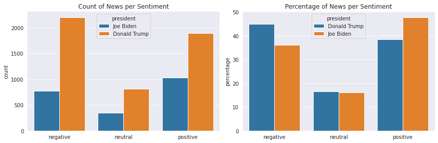

```python
fig, ax = plt.subplots(1, 2, figsize=(12, 4))

sns.countplot(data=df, x='vader_sentiment', hue='president', ax=ax[0])
ax[0].set_title('Count of News per Sentiment')
ax[0].xaxis.label.set_visible(False)

sns.barplot(
    x="vader_sentiment",
    y="percentage",
    hue="president",
    data=sentiment_counts,
    ax=ax[1]
)
ax[1].set_title('Percentage of News per Sentiment')
ax[1].xaxis.label.set_visible(False)
plt.tight_layout()
```

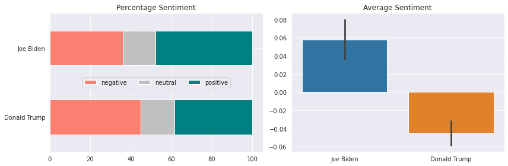

```python
fig, ax = plt.subplots(1, 2, figsize=(12, 4))

sentiment_counts.pivot_table(
    columns=['vader_sentiment'],
    index=['president'],
    values='percentage',
).plot(
    kind='barh',
    stacked=True,
    ax=ax[0],
    color={
        "negative": "salmon",
        "neutral": "silver",
        "positive": "teal"
    }
)
ax[0].set_title('Percentage Sentiment')
ax[0].yaxis.label.set_visible(False)
ax[0].legend(loc="center", ncol=3)

sns.barplot(data=df, x='president', y='sentiment', ax=ax[1])
ax[1].set_title('Average Sentiment')
ax[1].yaxis.label.set_visible(False)
ax[1].xaxis.label.set_visible(False)
plt.tight_layout()
```

```python
sentiment_over_time.pivot_table(
    columns=['president', 'vader_sentiment'],
    index=['pub_month'],
    values='percentage'
)
```

| president vader_sentiment pub_month | Donald Trump negative | Donald Trump neutral | Donald Trump positive | Joe Biden negative | Joe Biden neutral | Joe Biden positive |
| --- | --- | --- | --- | --- | --- | --- |
| 1 | 47.933884 | 19.283747 | 32.782369 | 31.012658 | 20.253165 | 48.734177 |
| 2 | 46.951220 | 14.481707 | 38.567073 | 30.526316 | 17.368421 | 52.105263 |
| 3 | 41.682975 | 18.395303 | 39.921722 | 35.000000 | 17.307692 | 47.692308 |
| 4 | 40.090090 | 17.792793 | 42.117117 | 30.769231 | 20.512821 | 48.717949 |
| 5 | 41.584158 | 21.980198 | 36.435644 | 37.634409 | 16.666667 | 45.698925 |
| 6 | 46.849315 | 12.876712 | 40.273973 | 33.854167 | 15.104167 | 51.041667 |
| 7 | 43.718593 | 18.341709 | 37.939698 | 40.476190 | 11.904762 | 47.619048 |
| 8 | 54.504505 | 13.963964 | 31.531532 | 55.405405 | 9.459459 | 35.135135 |
| 9 | 41.486068 | 13.003096 | 45.510836 | 43.093923 | 12.707182 | 44.198895 |
| 10 | 48.255814 | 13.081395 | 38.662791 | 34.285714 | 17.142857 | 48.571429 |
| 11 | 40.202703 | 18.918919 | 40.878378 | 25.899281 | 18.705036 | 55.395683 |
| 12 | 43.511450 | 15.648855 | 40.839695 | 41.964286 | 9.821429 | 48.214286 |

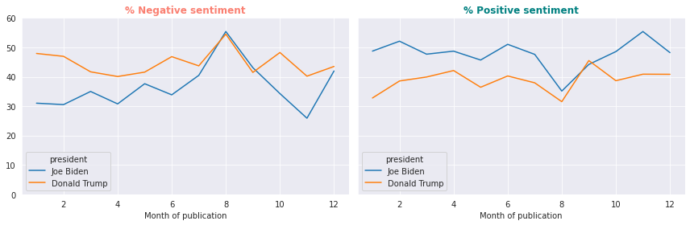

```python
fig, ax = plt.subplots(1, 2, figsize=(12, 4), sharey=True)

sns.lineplot(
    data=sentiment_over_time[sentiment_over_time['vader_sentiment']=='negative'],
    y='percentage',
    x='pub_month',
    hue='president',
    ax=ax[0],
)
ax[0].yaxis.label.set_visible(False)
ax[0].set_title('% Negative sentiment', color='salmon', fontweight='bold')
ax[0].set_xlabel('Month of publication')

sns.lineplot(
    data=sentiment_over_time[sentiment_over_time['vader_sentiment']=='positive'],
    y='percentage',
    x='pub_month',
    hue='president',
    ax=ax[1]
)
ax[1].set_title('% Positive sentiment', color='teal', fontweight='bold')
ax[1].set_xlabel('Month of publication')

plt.ylim(0, 60)
plt.tight_layout()
```

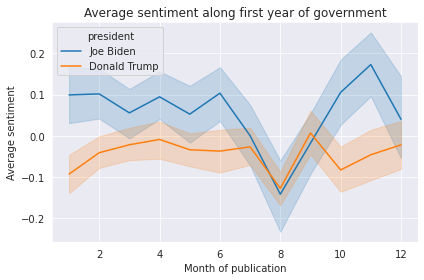

```python
sns.lineplot(data=df, y='sentiment', x='pub_month', hue='president')
plt.title('Average sentiment along first year of government')
plt.xlabel('Month of publication')
plt.ylabel('Average sentiment')
plt.tight_layout()
```

**Approval rates of Joe Biden and Donald Trump during first mandate year**, according to [FiveThirtyEight](https://projects.fivethirtyeight.com/biden-approval-rating/?ex_cid=rrpromo):

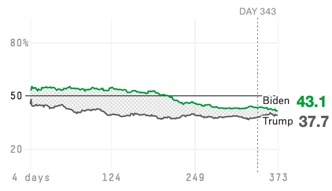

## 4.2. Word Cloud and Filtered Samples

The 4 different word clouds were generated using the Python library `WordCloud`, which is able to include bigram collocations as a single token in case both words co-occur too frequently.

While looking at the most frequent words in negative and positive headlines about Trump, expressions like "White House", "republican", "leader", "American" and "administration" appear quite often in both cases. Frequent expressions that are more exclusive to negative news are "travel ban", "war", "attack", "threat" and "North Korea", and filtered samples containing such words suggest that the journal used to criticize the former president for his international diplomacy.

In contrast to Trump's word cloud, Biden's positive headlines seem to be more about vaccinating the entire country against Covid-19 with a big investment, as suggested by the frequent expressions "vaccination", "trillion", "million", "pandemic" and "plan". On the other hand, "Afghanistan" and "climate change" are more exclusive of Biden's negative headlines. In case of samples containing "Afghanistan", the president was criticized for his decision of withdrawing American troops, which led to violent episodes and popular frustration. However, headlines containing "climate change" seem to be false negatives, because they carry mostly positive ideas but succeeded by the negative word "fight". This is one of the limitations of lexicon based approaches.

### Trump's Word Cloud

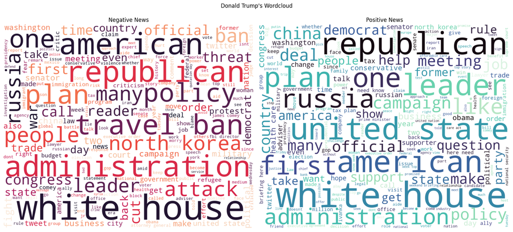

```python
sns.reset_defaults()

wordcloud_negative.generate(' '.join(trump_negative.apply(' '.join)))
wordcloud_positive.generate(' '.join(trump_positive.apply(' '.join)))

fig, ax = plt.subplots(1,2, figsize=(16, 8))
ax[0].axis("off")
ax[1].axis("off")

fig.suptitle("Donald Trump's Wordcloud")
ax[0].set_title("Negative News")
ax[1].set_title("Positive News")

ax[0].imshow(wordcloud_negative)
ax[1].imshow(wordcloud_positive)
plt.tight_layout()
```

```python
df[
   (df['headline_snippet'].map(lambda x: 'travel ban' in x))
   & (df['president']=='Donald Trump')
   & (df['vader_sentiment']=='negative')
][["pub_date", "headline.main", "snippet"]].sample(5, random_state=42)
```

|  | pub_date | headline.main | snippet |
| --- | --- | --- | --- |
| 4929 | 2017-06-26 | Supreme Court Takes On Trump Travel Ban | Adam Liptak, Supreme Court reporter for the Ne... |
| 5899 | 2017-09-08 | Appeals Court Limits Trump Travel Ban and Allo... | The court exempted grandparents, other family ... |
| 2667 | 2017-02-07 | About 20 Rabbis Arrested During Protest Over T... | Protesters in Manhattan sat down across an ave... |
| 2778 | 2017-02-11 | Erdogan Curbs Criticism of Trump, Seeking Warm... | President Recep Tayipp Erdogan of Turkey even ... |
| 4685 | 2017-06-04 | Trump’s Off-the-Cuff Tweets Strain Foreign Ties | After initial condolences, the president waste... |

```python
df[
   (df['headline_snippet'].map(lambda x: 'North Korea' in x))
   & (df['president']=='Donald Trump')
   & (df['vader_sentiment']=='negative')
][["pub_date", "headline.main", "snippet"]].sample(5, random_state=42)
```

|  | pub_date | headline.main | snippet |
| --- | --- | --- | --- |
| 5862 | 2017-09-05 | Trump’s Phone Buddy in North Korea Crisis: Shi... | The two leaders have chatted by telephone 13 t... |
| 4172 | 2017-05-03 | Why Trump’s Budding Bromance With Xi Is Doomed | Beneath the bonhomie, experts say, are differe... |
| 3250 | 2017-03-04 | Trump Inherits a Secret Cyberwar Against North... | The United States has been trying to sabotage ... |
| 3939 | 2017-04-20 | The North Korea-Trump Nightmare | It’s scary to consider what a frustrated presi... |
| 5493 | 2017-08-09 | Trump’s ‘Fire and Fury’ Warning to North Korea | Readers view North Korea’s threats as saber ra... |

```python
df[
   (df['headline_snippet'].map(lambda x: 'threat' in x))
   & (df['president']=='Donald Trump')
   & (df['vader_sentiment']=='negative')
][["pub_date", "headline.main", "snippet"]].sample(5, random_state=42)
```

|  | pub_date | headline.main | snippet |
| --- | --- | --- | --- |
| 3684 | 2017-04-01 | Conservative Split Over Import Tax Imperils Tr... | A proposed “border adjustment” tax is meeting ... |
| 2393 | 2017-01-28 | Can Donald Trump Handle the Truth? | Presidential denial is an even bigger threat t... |
| 5760 | 2017-08-24 | The Rift Between Trump and Congress | Readers criticize the president for threatenin... |
| 2499 | 2017-01-31 | San Francisco Sues Trump Over ‘Sanctuary Citie... | City officials say a threat to withhold fundin... |
| 6017 | 2017-09-21 | Critics Fear Trump’s Attacks on Iran Could Bac... | Critics of Mr. Trump’s threats to vacate the n... |

### Biden's Word Cloud

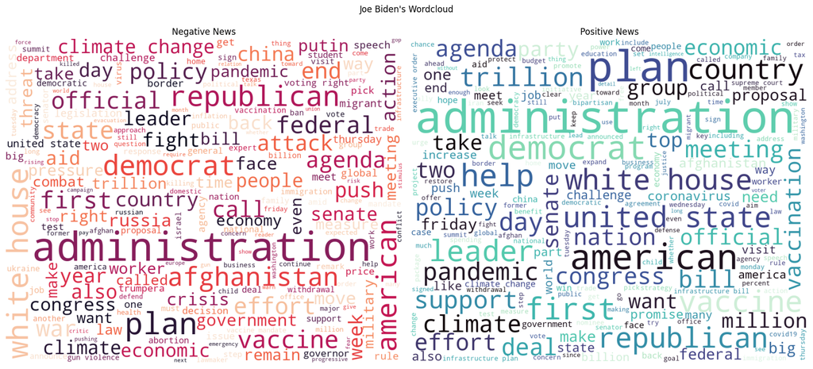

```python
wordcloud_negative.generate(' '.join(biden_negative.apply(' '.join)))
wordcloud_positive.generate(' '.join(biden_positive.apply(' '.join)))


fig, ax = plt.subplots(1,2, figsize=(16, 8))
ax[0].axis("off")
ax[1].axis("off")

fig.suptitle("Joe Biden's Wordcloud")
ax[0].set_title("Negative News")
ax[1].set_title("Positive News")

ax[0].imshow(wordcloud_negative)
ax[1].imshow(wordcloud_positive)
plt.tight_layout()
```

```python
df[
   (df['headline_snippet'].map(lambda x: 'Afghanistan' in x))
   & (df['president']=='Joe Biden')
   & (df['vader_sentiment']=='negative')
][["pub_date", "headline.main", "snippet"]].sample(5, random_state=42)
```

|  | pub_date | headline.main | snippet |
| --- | --- | --- | --- |
| 1493 | 2021-08-15 | In Washington, Recriminations Over Afghanistan... | President Biden is finding few outspoken defen... |
| 1561 | 2021-08-29 | Biden Receives Bodies of Service Members Kille... | The president’s first trip in office to witnes... |
| 1620 | 2021-09-09 | Trump produces a week of mixed messaging as he... | The former president has sought to project pat... |
| 752 | 2021-04-19 | Biden, debating exit from Afghanistan, rejecte... | Over two decades of war, the Pentagon had fend... |
| 1571 | 2021-08-31 | Biden Didn’t See the ISIS-K Threat in Afghanis... | Twenty years later, the terrorism threat from ... |

```python
df[
   (df['headline_snippet'].map(lambda x: 'climate change' in x))
   & (df['president']=='Joe Biden')
   & (df['vader_sentiment']=='negative')
][["pub_date", "headline.main", "snippet"]].sample(5, random_state=42)
```

|  | pub_date | headline.main | snippet |
| --- | --- | --- | --- |
| 86 | 2021-01-25 | Biden Sets in Motion Plan to Ban New Oil and G... | The president will announce a suite of executi... |
| 597 | 2021-03-31 | Biden’s Climate Plan Means Tough Choices: Whic... | The proposal represents an enormous effort to ... |
| 1655 | 2021-09-13 | In California, Worsening Fires Show Limits of ... | Despite a visit meant to emphasize his actions... |
| 116 | 2021-01-27 | Here’s what Biden’s pick for energy secretary ... | NaN |
| 1597 | 2021-09-05 | Biden to Visit Northeast Flood Zones as Demand... | The president will visit hard-hit areas in New... |

```python
df[
   (df['headline_snippet'].map(lambda x: 'vaccination' in x))
   & (df['president']=='Joe Biden')
   & (df['vader_sentiment']=='positive')
][["pub_date", "headline.main", "snippet"]].sample(5, random_state=42)
```

|  | pub_date | headline.main | snippet |
| --- | --- | --- | --- |
| 751 | 2021-04-19 | Adults in all U.S. states are now eligible for... | Hawaii, Massachusetts, New Jersey, Oregon, Rho... |
| 2043 | 2021-12-03 | Emphasizing Tests, Biden Vows to Fight Omicron... | The president’s plan shifts away from a near-s... |
| 643 | 2021-04-06 | Biden Visits Virginia Vaccination Site | President Biden visited a vaccination clinic i... |
| 1923 | 2021-11-03 | Biden urges vaccinations for millions of newly... | A vaccination program for children will roll o... |
| 90 | 2021-01-26 | Biden Raises Daily Vaccination Target and Exte... | President Biden now says he hopes to administe... |

# 5. Conclusion

Despite its low accuracy when faced against the gold standard, VADER classifications can be considered a useful tool for sentiment analysis and a good thermometer for public opinion. Both average sentiment and percentage of positive/negative headlines behaved as expected, considering presidential approval rates as benchmark. This reasoner captured that Donald Trump accumulated more negative sentiment in New York Times headlines during his first mandate year than his successor, but also that Joe Biden faced popularity issues in August 2021.

However, it has limitations as any Lexicon based approach. Words that are generally ranked as negative, can also be used to negate other negative expressions - VADER deals with common negations, like "no" and "not", but cases like "fight climate change" seem to be classified as negative. Such cases would only be captured by more advanced techniques, trained on large labeled datasets of political domain. All pre-trained models tested in this project were mostly built on either social media (mainly Twitter) and/or movie reviews datasets, which might not share exactly the same political vocabulary as a newspaper.

The main suggestions of next steps for similar projects are the use of a larger and more reliable (higher Krippendorff's alpha) dataset to use as gold standard, and training different Deep Learning models on these labels. Word Embeddings, LSTM and transformers might be good candidates for the task, as they are state-of-the-art techniques.

# 6. References

- Akbik, A., Blythe, D. & Vollgraf, R (2018). Contextual String Embeddings for Sequence Labeling. Coling, page 1638-1649.
- Boukes, M., van de Velde, B., Araujo, T. & Vliegenthart, R. (2020) What’s the Tone? Easy Doesn’t Do It: Analyzing Performance and Agreement Between Off-the-Shelf Sentiment Analysis Tools, Communication Methods and Measures, 14:2, 83-104, DOI: 10.1080/19312458.2019.1671966 [Taylor & Francis Online](https://www.tandfonline.com/doi/ref/10.1080/19312458.2019.1671966)
- Cohen, J. (1960). A coefficient of agreement for nominal scales. Educational and Psychological Measurement. doi:10.1177/001316446002000104.
- Hutto, C.J. & Gilbert, E.E. (2014). VADER: A Parsimonious Rule-based Model for Sentiment Analysis of Social Media Text. Eighth International Conference on Weblogs and Social Media (ICWSM-14). Ann Arbor, MI, June 2014.
- Krippendorff, K. (1970). Estimating the reliability, systematic error, and random error of interval data. Educational and Psychological Measurement, 30 (1).
- Krippendorff, K. (2012). Content analysis: An introduction to its methodology. Sage.
- Van Atteveldt, W., van der Velden, M. A. C. G. & Boukes, M. (2021) The Validity of Sentiment Analysis: Comparing Manual Annotation, Crowd-Coding, Dictionary Approaches, and Machine Learning Algorithms, Communication Methods and Measures, 15:2, 121-140, DOI: 10.1080/19312458.2020.1869198 [Taylor & Francis Online](https://www.tandfonline.com/doi/full/10.1080/19312458.2020.1869198)